# HDS-5330 Assignment_3

```python
import pandas as pd
import matplotlib.pyplot as plt
import seaborn as sns
import numpy as np
from sklearn.linear_model import LinearRegression

#Read the data
df = pd.read_csv('Data_Assignment3.csv')
df.head()
```

|  | ID | DOB | Age At Surgery | Gender | Race |
| --- | --- | --- | --- | --- | --- |
| 0 | 1 | 1937-05-09 | 79 | 1 | 5 |
| 1 | 2 | 1952-02-15 | 64 | 1 | 2 |
| 2 | 3 | 1934-05-04 | 82 | 1 | 5 |
| 3 | 4 | 1941-11-10 | 74 | 2 | 2 |
| 4 | 5 | 1944-01-20 | 72 | 1 | 1 |

```python
# 1: Linear Regression
X = df[['Gender', 'Race']]
y = df['Age At Surgery']

model = LinearRegression().fit(X, y)

print('1. Linear Regression Equation:')
print(f'Age At Surgery = {model.intercept_:.2f} + {model.coef_[0]:.2f} * Gender + {model.coef_[1]:.2f} * Race')
```

```
1. Linear Regression Equation:
Age At Surgery = 82.30 + -10.96 * Gender + 0.21 * Race
```

# This equation shows how Age At Surgery is related to Gender and Race. The negative coefficient for Gender (-10.96) suggests that, on average, males have surgery about 11 years earlier than females. The small positive coefficient for Race (0.21) indicates a slight increase in surgery age as the race category number increases, but this effect is much smaller compared to the gender effect.

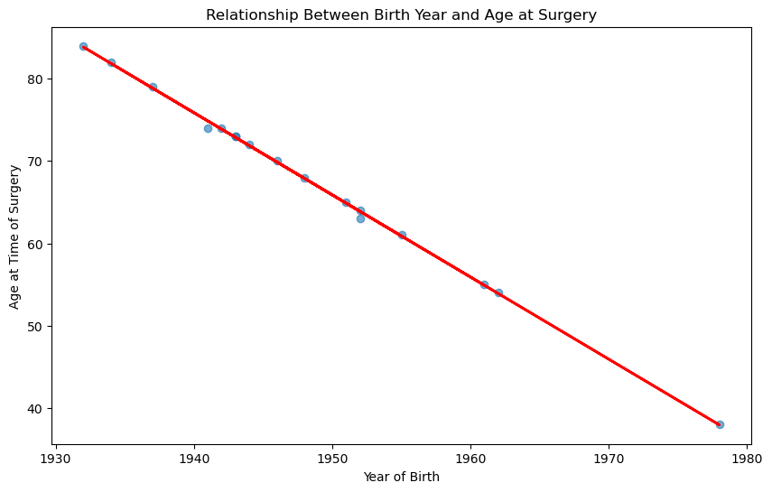

```python
#Linear Regression: DOB vs Age at Surgery
df['DOB'] = pd.to_datetime(df['DOB'])
birth_years = df['DOB'].dt.year.values.reshape(-1, 1)
surgery_ages = df['Age At Surgery'].values

model = LinearRegression()
model.fit(birth_years, surgery_ages)

plt.figure(figsize=(10, 6))
plt.scatter(birth_years, surgery_ages, alpha=0.6)
plt.plot(birth_years, model.predict(birth_years), color='red', linewidth=2)
plt.xlabel('Year of Birth')
plt.ylabel('Age at Time of Surgery')
plt.title('Relationship Between Birth Year and Age at Surgery')

plt.show()
```